# Reliability slides

## Reliability and Security of Deep Neural Networks

###### $\color{blue}{\text{Masoud Daneshtalab:}}$ Professor at Mälardalen University and TalTech

###### $\color{blue}{\text{Seyedhamidreza Mousavi:}}$ PhD student at Malardalan University

###### $\color{blue}{\text{Mohammad Hassan Ahmadilivani (Mojtaba):}}$ Postdoctoral researcher at TalTech University

###### $\color{blue}{\text{Email:}}$ masoud.daneshtalab@mdu.se, seyedhamidreza.mousavi@mdu.se, mohammad.ahmadilivani@taltech.ee

### Reliability and security threats to machine learning-based systems

[figure not shown]

**We are going to focus on two threats:**

- **Reliability issues (Hardware Faults) --> RReLU Framework**
- **Adversarial input perturbation --> ProARD Framework**

## First Part: Reliable ReLU Toolbox (RReLU) To Enhance Resilience of DNNs

## What is a Deep Neural Network?

[figure not shown]

## The application of DNNs: **Object Detection**

[figure not shown]

## What is the Soft-errors problem?

[figure not shown]

## ❓ What is the issue with ReLU?

[figure not shown]

## ✅ What is the solution?

[figure not shown]

**❓How can we find the bound value for each ReLU activation function?**

**❓If the output activation is higher than bound, what should we do?**

**❓IS there any real situation that changed the activation value a lot?**

**❓Do we need to find one bound value for each layer or neuron?**

## Data representation in Neural Network

## Fixed-Point Number

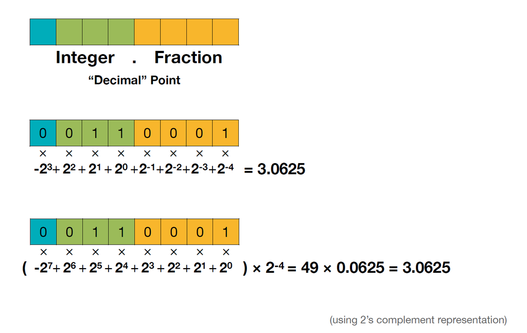

## Floating-Point Number

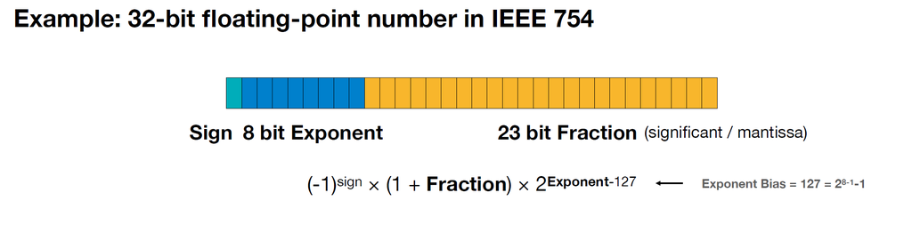

## Activation Restriction Methods:

- **Bounded ReLU activation functions:**

[figure not shown]

- **Algorithm for finding the bounds:**
  - Ranger used the calibration method in a layer-wise way.
  - FT-ClipAct used a heuristic method based on fault-injection in a layer-wise manner.
  - FitAct leveraged an optimisation-based method in a neuron-wise mode.
  - **ProAct used a Hybrid activation function (neuron-wise and layer-wise) and progressive training**

### ProAct provide an Open-Source Framework for all the Methods (RReLU)

It includes implementations of the following algorithms:

1. **[FitAct: Error Resilient Deep Neural Networks via Fine-Grained Post-Trainable Activation Functions](https://arxiv.org/pdf/2112.13544)**
2. **[FT-ClipAct: Resilience Analysis of Deep Neural Networks and Improving their Fault Tolerance using Clipped Activation](https://arxiv.org/pdf/1912.00941)**
3. **[Ranger: A Low-cost Fault Corrector for Deep Neural Networks through Range Restriction](https://arxiv.org/pdf/2003.13874)**
4. **[ProAct: Progressive Training for Hybrid Clipped Activation Function to Enhance Resilience of DNNs](https://arxiv.org/pdf/2406.06313)**

## How do different methods work?

#### **Ranger**: Find the maximum value for a validation set and use that value as the bound in each ReLU.

#### **FT-ClipAct**:

[figure not shown]

#### **FitAct**:

[figure not shown]

#### **ProAct**:

[figure not shown]

## Instructions to use RReLU framework

## Install Packages and Clone the RReLU Github Repository

```python
!pip install fxpmath
!git clone https://github.com/hamidmousavi0/reliable-relu-toolbox.git
%cd reliable-relu-toolbox/
```

## Build Data Loader

First, we need to create the Dataset

```python
from rrelu.setup import build_data_loader
data_loader_dict, n_classes = build_data_loader(dataset='cifar10',
                                    batch_size=128, image_size=32)
import matplotlib.pyplot as plt

# Get the first batch from the training data loader
images, labels = next(iter(data_loader_dict['train']))

# Get the class names for CIFAR-10
# This assumes CIFAR-10 is used as specified in the previous cell
class_names = ['airplane', 'automobile', 'bird',
               'cat', 'deer', 'dog', 'frog',
               'horse', 'ship', 'truck']


# plt.figure(figsize=(10,10))
# for i in range(25):
#     plt.subplot(5,5,i+1)
#     plt.xticks([])
#     plt.yticks([])
#     plt.grid(False)
#     # Transpose the image tensor to be in HxWxC format for plotting
#     plt.imshow(images[i].permute(1, 2, 0))
#     # The CIFAR10 labels are indices, so we use the class_names list
#     plt.xlabel(class_names[labels[i].item()])
# plt.show()
```

## Build Model

- Our tool support pre-trained models on CIFAR-10, CIFAR-100, and ImageNet Dataset
- Cifar-10 and Cifar-100 supported models:
  - resnet20, resnet32, resnet44, resnet56
  - vgg11_bn, vgg13_bn, vgg16_bn, vgg19-bn
  - mobilenetv2_x0_5, mobilenetv2_x0_75
  - shufflenetv2_x1_5
- ImageNet supported Models:
  - All the models in the PyTorch-hub

```python
from rrelu.setup import build_model
model = build_model(name='resnet20',dataset='cifar10',
                    n_classes=n_classes)
print(model)
```

## Evaluate the original Model with ReLU activation function

```python
from metrics import eval_,eval

print(eval_(model,data_loader_dict,'cuda'))
```

## Convert Floating-Point weight values to the Fixed-Point

```python
import torch
from fxpmath import Fxp
with torch.no_grad():
    for name, param in model.named_parameters():
        if param is not None:
            param.copy_(torch.tensor(Fxp(param.clone().cpu().numpy(),
                    True, n_word=32, n_frac=16, n_int=15).get_val(),
                                     dtype=torch.float32,device='cpu'))
```

## Evaluate the Fixed-Point Model

```python
print(eval_(model, data_loader_dict,'cuda'))
```

## Evaluating Reliability of the model

```python
from metrics import eval_fault_
print(eval_fault_(model, data_loader_dict,
                     1e-6, bitflip='fixed',iterations=5,device='cuda'))
```

## Build the model with Reliable ReLU

```python
from rrelu.setup import replace_act
from metrics import eval_fault_
model = replace_act(model, 'proact', 'proact', data_loader_dict,
                    'layer', 'fixed',False ,'cifar10',is_root=True,device='cuda')
print(eval_fault_(model, data_loader_dict, 1e-6,
                     bitflip='fixed',iterations=5,device='cuda'))
```

```python
# rm -r reliable-relu-toolbox/
```

## Results of using different methods:

[figure not shown]

**[GitHub project: reliable-relu-toolbox](https://github.com/hamidmousavi0/reliable-relu-toolbox)**

**[Paper link: ProAct: Progressive Training for Hybrid Clipped Activation Function to Enhance Resilience of DNNs](https://arxiv.org/abs/2406.06313)**

## Second Part: ProARD: Progressive Adversarial Robustness Distillation: Provide Wide Range of Robust Students

### How about the perturbation in the input data? How can we defend against this type of attacks?

[figure not shown]

## The state-of-the-art method is Adversarial Training.

**The state-of-the-art methods are:**

- TRADES: Theoretically Principled Trade-off between Robustness and Accuracy
- ARD: Adversarial Robustness Distillation: Use a Robust Teacher Network to train the student's networks. (**What is the issue?**)

[figure not shown]

## Is it possible to train a single robust supernetwork and extract multiple robust subnetworks from it, each tailored to different resource-constrained devices—without requiring retraining?

#### How should we train this super-network?

- Randomly sample subnetworks from the supernetwork, train them independently, and return their updates to the supernetwork using weight sharing.
- Does it work?

## First step: Making Super Dynamic Network:

[figure not shown]

### If we trained the multiple subnetworks inside a supernetwork by randomly subsampling, what would be their accuracy and robustness?

[figure not shown]

**We propose Progressive Adversarial Robustness Distillation (ProARD).**

**Enabling the efficient one-time training of a dynamic network that supports a diverse range of accurate and robust student networks without requiring retraining.**

#### ProARD: Progressive Adversarial Robustness Distillation: Provide Wide Range of Robust Students

[figure not shown]

**[Project code:ProARD: Progressive Adversarial Robustness Distillation: Provide Wide Range of Robust Students](https://github.com/hamidmousavi0/Robust_OFA)**

## Results

[figure not shown]

### Coding Part

```python
!git clone https://github.com/hamidmousavi0/Robust_OFA.git
```

```python
!pip install git+https://github.com/jeromerony/adversarial-library
```

```python
!pip install adversarial-robustness-toolbox
```

```python
!pip install torchprofile
!pip install torchpack
```

```python
!pip install git+https://github.com/fra31/auto-attack
```

```python
cd Robust_OFA/
```

```python
import gdown
gdown.download("https://drive.google.com/uc?export=download&id=1Z7HdxG-Wwg54xQRcLZXSBNlxLvBDjduZ","model_best.pth.tar")
```

```python
mv model_best.pth.tar exp/robust/cifar10/ResNet50/trades/width_depth2width_depth_width/phase2/checkpoint/
```

```python
!python eval_ofa_net.py
```